# Marine Habitat Classification Using Deep Learning - Classifying VME Indicators in Underwater Images

### 6.6 Overall Class Performance

Below, we visualise our overall Class Performance

```
Error loading image vme_dataset/test/coral/205c5b40-20f1-4007-9afa-53fc02076183.png: image file is truncated
```

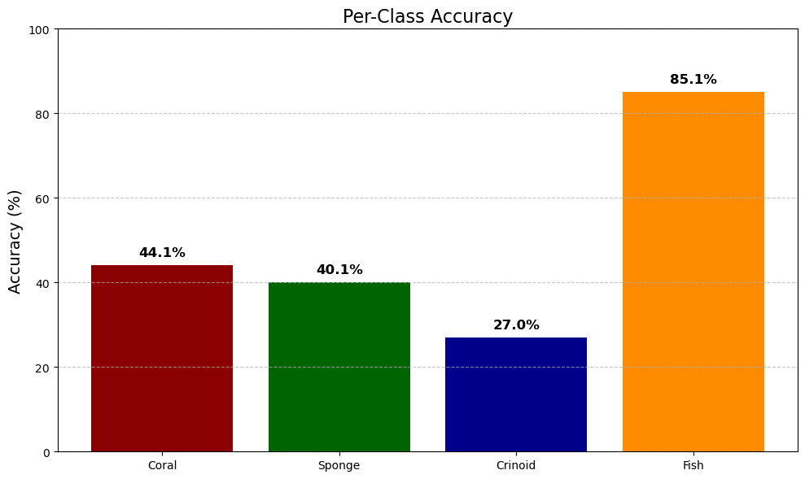

```python
def plot_per_class_accuracy(model, test_loader):
    """Calculate and plot the accuracy for each class"""

    class_names = test_dataset.categories
    class_names = [name.capitalize() for name in class_names]

    device = torch.device("cuda" if torch.cuda.is_available() else "cpu")
    model = model.to(device)
    model.eval()

    class_correct = [0] * len(class_names)
    class_total = [0] * len(class_names)

    with torch.no_grad():
        for inputs, labels in test_loader:
            inputs, labels = inputs.to(device), labels.to(device)
            outputs = model(inputs)
            _, predictions = torch.max(outputs, 1)

            for i in range(len(labels)):
                label = labels[i].item()
                class_total[label] += 1
                if predictions[i] == labels[i]:
                    class_correct[label] += 1

    # Calculate accuracy for each class
    accuracies = []
    for i in range(len(class_names)):
        accuracy = 100 * class_correct[i] / max(class_total[i], 1)  # Avoid division by zero
        accuracies.append(accuracy)

    # Plot bar chart
    plt.figure(figsize=(10, 6))
    colors = ['#8B0000', '#006400', '#00008B', '#FF8C00']  # Custom colors for each class
    bars = plt.bar(class_names, accuracies, color=colors)

    # Add accuracy values
    for bar, val in zip(bars, accuracies):
        plt.text(bar.get_x() + bar.get_width()/2, val + 2, f"{val:.1f}%",
                ha='center', fontweight='bold', fontsize=12)

    plt.title('Per-Class Accuracy', fontsize=16)
    plt.ylabel('Accuracy (%)', fontsize=14)
    plt.ylim(0, 100)
    plt.grid(axis='y', linestyle='--', alpha=0.7)
    plt.tight_layout()
    plt.savefig("per_class_accuracy.png", dpi=300)
    plt.show()

    return class_correct, class_total

# Plot the per-class accuracy
class_correct, class_total = plot_per_class_accuracy(best_model, test_loader)
```

### 6.6.1 Overall Class Performance Analysis

The per-class accuracy visualisation reveals an interesting performance differences across the four VME indicator classes:

- **Fish (85.1%)** show the highest recognition rate by a significant margin
- **Coral (44.1%)** and **Sponge (40.1%)** are identified with moderate accuracy
- **Crinoids (27.0%)** have the lowest recognition rate

The disparity in performance likely due to the following reasons:

1. **Distinctive morphology**: Fish have highly distinctive body shapes and fin structures that stand out even in challenging underwater conditions
2. **Feature consistency**: The higher learning rate may have allowed the model to better capture the consistent patterns in fish anatomy
3. **Environmental context**: Fish typically appear in the water column rather than against variable seafloor backgrounds, potentially reducing confounding features
4. **Dataset representation**: The training examples for fish may have had better quality or more consistent imaging conditions

The persistent challenge with crinoid recognition suggests that these organisms remain difficult to classify even with optimised parameters, possibly due to their visual similarity to both corals and certain fish depending on the viewing angle.